# Testing for Tolerance

**Jason Sheppard**

## Research Question

What tolerance value produces the most realistic-looking graphs that align with our expectations of stable and unstable behavior?

## Stable Orbit Definition

A 'Stable' orbit refers to an orbit where an electron completes a full orbit such that when $x = x_{initial}$ our difference, $|y-y_{initial}|$ is less than our chosen tolerance value.

## Shape detection

We choose how to define the shape of an orbit by checking if the electron goes between both protons, below the lower, both or neither. This gives us the 4 orbit shapes of around 1 proton, racetrack around both, figure 8 or an instant exit respectively. We can see that later on, this initial assumtion falls apart as more shapes appear.

## Configuration

1 Electron at $(x,y) = (0,2)$ and 2 Protons $(x,y) = (0,1),(0,-1)$

## Scale

All values (mass of particles and G) have been scaled so we can use $x=a[m]$ and $v = a[m/s]$

# Start of Code

## Initial parameters

```python
#Importing
import numpy as np
import matplotlib.pyplot as plt
from scipy.integrate import solve_ivp
import pandas as pd

#SCALED VALUES - used in ODE
m_e = 4.4e-11
m_p = 8e-8
G = 3.2e9

#Position of Protons
fixed_points = [(0.0, -1.0),
                (0.0, 1.0)]
```

# Functions and Calculations

## ODE

```python
n_orbit = 0
def diff_eqns(t, state):
    x = state[0]
    y = state[1]
    vx = state[2]
    vy = state[3]

    global n_orbit
    dxdt = vx
    dydt = vy

    dvxdt = 0
    dvydt = 0


    for (xf, yf) in fixed_points:

        r = np.sqrt((x-xf)**2 + (y-yf)**2)
        u_x = (x - xf) / r
        u_y = (y - yf) / r

        dvxdt -= ((G * m_p) / r**2 ) * u_x  #acceleration x
        dvydt -= ((G * m_p) / r**2 ) * u_y  #acceleration y




    return dxdt, dydt, dvxdt, dvydt
```

## Plotting one specific orbit

```python
def plot_func(sol1, num_graph = 0, scale = 1):

    if scale == 0:
        scale = 1         # Safety condition

    # EXTRACTING DATA FROM SOLVE_IVP
    state_results = sol1['y']
    x_results = state_results[0]
    y_results = state_results[1]

    # Creating plots
    fig, ax = plt.subplots(1, 1, figsize=(8, 8))

    # Position of electron path and start
    ax.plot(x_results, y_results, color='b')
    ax.scatter(state0[0], state0[1], label = 'START')

    # Position of Protons
    for (xt, yt) in fixed_points:
        ax.scatter(xt, yt, label = 'PROTON', color = 'k')



    #Thing tested by plots (mystery points)
    #ax[0].plot((0,0),(-1,1), color = 'red', label = 'Fig 8 Detection Lion')          #Visual representation of between line
    #ax[0].scatter(0,0, color = 'k', zorder = 4)
    #ax[0].scatter(-1.6653345369377348e-16, 7.57465938251295e-05, color = 'r', zorder = 4, label = 'MYSTERY POINT')
    #ax[0].scatter(-7.92715965e-01, 1.00000000e+00, color = 'r', zorder = 4, label = 'MYSTERY POINT')

    # Finish graphing
    ax.set_xlim(-3.1/scale,3.1/scale)
    ax.set_ylim(-3.1/scale,3.1/scale)
    ax.set_title(f'[{num_graph}]') # Used to label graphs so they can be refered to later
    ax.legend()
```

## Describing each orbit (Returning a number for graphing later)

```python
def shape_num(sol1, tolerance):
    # Initializing var
    between_bool = False
    below_bool = False
    stable = True

    # Did the electrons cross the y-axis between protons?
    # Did it cross below the lower?
    crossings = sol1.y_events[0]
    for event in crossings:
        y = event[1]
        if 1 > y > -1:
            between_bool = True
        if y < -1:
            below_bool = True

    # Did the electron cross the y-axis above the upper proton while being within 'tolerance' of its initial position?
    directions = sol1.y_events[1]
    for event in directions:
        y = event[1]
        if abs(y - 2) > tolerance and y > 1:
            stable = False
            break
    # Did the electron only cross once? (Flew off screen)
    if len(sol1.t_events[1]) <= 1:
        stable = False




    # Returning values according to logic from above

    # Flew off screen
    if len(sol1.t_events[2]) > 0 or len(sol1.t_events[3]) > 0 or len(sol1.t_events[4]) > 0 or len(sol1.t_events[5]) > 0:
        return 0


    if below_bool and between_bool and stable:
        # Figure 8 - stable
        return 1
    elif between_bool and stable:
        # Around 1 - stable
        return 2
    elif below_bool and stable:
        # Racetrack - stable
        return 3
    # No case of stable orbit without going between or below
    elif below_bool and between_bool and not stable:
        # Figure 8 - unstable
        return 4
    elif between_bool and not stable:
        # Around 1 - Unstable
        return 5
    elif below_bool and not stable:
        # Racetrack - Unstable
        return 6
    else:
        # Wont ever run, just a catch all else statement (unsure if these are needed in python)
        return 0
```

## Describing each orbit (Same as above but returns a string description)

```python
def shape_checker(sol1, tolerance):
    between_bool = False
    below_bool = False
    stable = True
    string = ''

    crossings = sol1.y_events[0]
    for event in crossings:
        y = event[1]
        if 1 > y > -1:
            between_bool = True
        if y < -1:
            below_bool = True

    directions = sol1.y_events[1]
    for event in directions:
        y = event[1]
        if abs(y - 2) > tolerance and y > 1:
            stable = False
            break
    if len(sol1.t_events[1]) <= 1:
        stable = False

    if len(sol1.t_events[2]) > 0 or len(sol1.t_events[3]) > 0 or len(sol1.t_events[4]) > 0 or len(sol1.t_events[5]) > 0:
        return 'Electron flew off screen (Unstable)'

    if below_bool and between_bool:
        string += 'Figure 8'
    elif below_bool:
        string += 'Race Track'
    elif between_bool:
        string += 'Orbit around one proton'

    if stable:
        return 'Stable ' + string
    else:
        return 'Unstable ' + string
```

## Solve_Ivp Events

```python
# Used for crossing between or below
def cross(t, state):
    x, y, vx, vy = state
    return x
cross.terminal = False
cross.direction = 0


# Used for checking for stability (could reuse above - no difference)
def stability(t, state):
    x, y, vx, vy = state
    return x
stability.terminal = False
stability.direction = 0


# Does the electron go too far right, left, up, down (below)?
def distance_r(t, state):
    x, y, vx, vy = state
    return x - 3
distance_r.terminal = True
distance_r.direction = 1

def distance_l(t, state):
    x, y, vx, vy = state
    return x + 3
distance_r.terminal = True
distance_r.direction = -1

def distance_u(t, state):
    x, y, vx, vy = state
    return y - 3
distance_r.terminal = True
distance_r.direction = 1

def distance_b(t, state):
    x, y, vx, vy = state
    return y + 3
distance_r.terminal = True
distance_r.direction = -1
```

## Calculations (~2hrs) (Option 1 to get results)

```python
# This window works with two nest for loops,
# the outer loop runs 10 times for 10 tolerance values (0.001 - 0.512)
# the inner loop represents running the solve_ivp calculation for all initial velocities
# from 12m/s to 24m/s (any values outside this range return unstable and are pointless in calculating)


# results/findings go in here
results_to_graph = []
nums_to_graph = []
# runs ~2-3 orbits for each test - any more is repetitive, any less is inconclusive
t_span = (0,3)
# used for testing - no impact on final results
scale = 1
# initial tolerance value
value = 0.001
for each in range(10):
    tol = value * (2**each) # finding each tol per iteration
    for vel in range(1200,2401):
        v0 = vel / 100      # finding each v0 per iteration
        # solve_IVP calculations
        state0 = (0, 2, v0, 0)
        sol1 = solve_ivp(diff_eqns, t_span, state0, rtol=1e-9, atol=1e-9, events = [cross, stability, distance_r, distance_l, distance_u, distance_b])
        # saving results
        results_to_graph.append([v0, tol])
        nums_to_graph.append(shape_num(sol1, tol))

    # To make sure its actually running
    print(f'Updater, {each}/9')
```

```
Updater, 0/9
Updater, 1/9
Updater, 2/9
Updater, 3/9
Updater, 4/9
Updater, 5/9
Updater, 6/9
Updater, 7/9
Updater, 8/9
Updater, 9/9
```

### Reading CSV File (Created in next function) (Option 2 to get results)

```python
df = pd.read_csv('VxTData.csv')
results_to_graph = df.iloc[:, :2].to_numpy()
nums_to_graph = df.iloc[:, 2].to_numpy()

# Variables are undefined if calculations code block is not run
t_span = (0,3)
scale = 1
```

### Graphing all data points (Optional csv creation)

```python
def plot_results(results, nums):
    # Parsing data
    results = np.array(results)
    nums = np.array(nums)
    velo  = results[:, 0]
    tol = results[:, 1]

    # Colors and labels for each different type of orbit
    col = ['r', 'pink', 'b', 'm', 'k', 'orange', 'g']
    labels = ['Unstable Exit', 'Stable Figure 8', 'Stable around 1 proton', 'Stable RaceTrack', 'Unstable Figure 8', 'Unstable around 1 proton', 'Unstable RaceTrack',]

    # Creating graph
    f, ax = plt.subplots(1, 1, figsize=(8, 8)) #1 plot

    # Setting y-axis scale
    yticks = np.array([0.001, 0.002, 0.004, 0.008, 0.016, 0.032, 0.064, 0.128, 0.256, 0.512])
    ax.set_yscale('log', base=2)  # <-- makes y-axis double each tick
    ax.set_yticks(yticks)
    ax.set_yticklabels(yticks)
    ax.set_ylabel('Tolerance')
    ax.set_xlabel('Velocity')

    # Making the 'Interesting' (stable) points in front
    for i in range(0,7):
        if i == 1 or i ==2 or i ==3:
            ax.scatter(velo[nums == i], tol[nums == i], color = col[i], label = labels[i], zorder = 4)
        else:
            ax.scatter(velo[nums == i], tol[nums == i], color = col[i], label = labels[i])
    ax.legend()
    ax.set_title('Shapes for different Velocities and Tolerances [1]')

    #SAVING DATA (takes too long to run data calculations each time
    SaveData = False
    if SaveData:
        plt.savefig("V0 x Tol Graph.png", dpi=300, bbox_inches='tight', transparent=False)
        data1 = {'Velocities': velo, 'Tolerances': tol, 'Num': nums}
        data2 = {'Colors': col, 'Labels': labels}
        df1 = pd.DataFrame(data1)
        df2 = pd.DataFrame(data2)
        df1.to_csv('VxTData.csv', index=False)
        df2.to_csv('ColorsAndLabels.csv', index=False)
```

### Graphing all data points (With highlighted points to be examined later)

```python
def plot_results_highlight(results, nums):
    results = np.array(results)
    nums = np.array(nums)
    velo  = results[:, 0]
    tol = results[:, 1]
    col = ['r', 'pink', 'b', 'm', 'k', 'orange', 'g']
    labels = ['Unstable Exit', 'Stable Figure 8', 'Stable around 1 proton', 'Stable RaceTrack', 'Unstable Figure 8', 'Unstable around 1 proton', 'Unstable RaceTrack',]

    # Highlighted Points
    vs = [14.62, 20.65, 21.91, 12.97, 13.15, 17.19]
    tols = [0.002, 0.016, 0.512, 0.064, 0.016, 0.016]

    f, ax = plt.subplots(1, 1, figsize=(8, 8)) #1 plot
    yticks = np.array([0.001, 0.002, 0.004, 0.008, 0.016, 0.032, 0.064, 0.128, 0.256, 0.512])
    ax.set_yscale('log', base=2)
    ax.set_yticks(yticks)
    ax.set_yticklabels(yticks)
    ax.set_ylabel('Tolerance')

    # Making highlighted points (before other points for clean legend)
    for i in range (6):
        if i == 0:
            ax.scatter(vs[i], tols[i], color = 'aqua', zorder = 5, label = 'Highlighted Points (6 of them)')
            ax.legend()
        else:
            ax.scatter(vs[i], tols[i], color = 'aqua', zorder = 5)

    for i in range(0,7):
        if i == 1 or i ==2 or i ==3:
            ax.scatter(velo[nums == i], tol[nums == i], color = col[i], zorder = 4)
        else:
            ax.scatter(velo[nums == i], tol[nums == i], color = col[i],)
    ax.set_title('Highlighted Points to be Analyzed [2]')
```

### Printing interesting values (Used to find highlighted values above)

```python
# By changing the last number on the last line and uncommenting code,
# I was able to print all points for each orbit description and choose ones to investigate

def intresting_values(results, nums, i):
    results = np.array(results)
    nums = np.array(nums)
    velo  = results[:, 0]
    tol = results[:, 1]
    #print(velo[nums == i], tol[nums == i])
#intresting_values(results_to_graph, nums_to_graph, 1)
```

## Results/Investigation - note numbered graphs

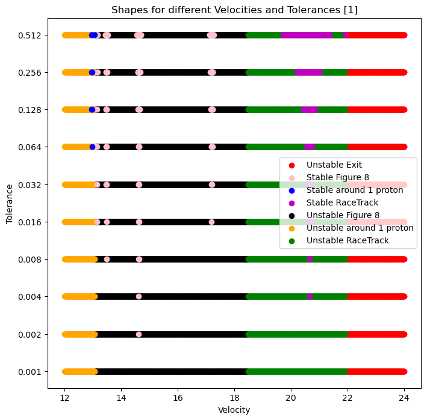

```python
plot_results(results_to_graph, nums_to_graph)
```

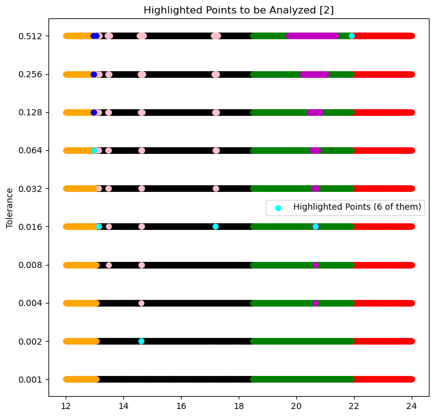

```python
plot_results_highlight(results_to_graph, nums_to_graph)
```

### Stable Figure 8 when = 0.002 (High quality orbit)

```
'Stable Figure 8'
```

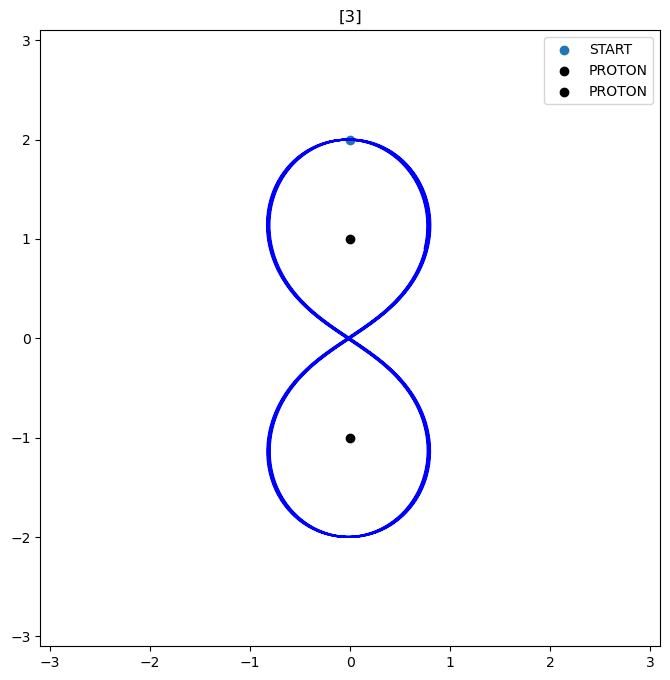

```python
# v0 and tol have been set to correspond to a highlighted point (above)
v0 = 14.62
tol = 0.002
# number that refers to this graph
graph_num = 3

# setting solve_ivp initial var
state0 = (0, 2, v0, 0)
# calling solve ivp
sol1 = solve_ivp(diff_eqns, t_span, state0, rtol=1e-9, atol=1e-9, events = [cross, stability, distance_r, distance_l, distance_u, distance_b])

# calling functions from above (plotting the orbit and labeling the orbit)
plot_func(sol1, graph_num, scale)
shape_checker(sol1, tol)
```

### Stable Racetrack when tolerance = 0.016 (High quality orbit)

```
'Stable Race Track'
```

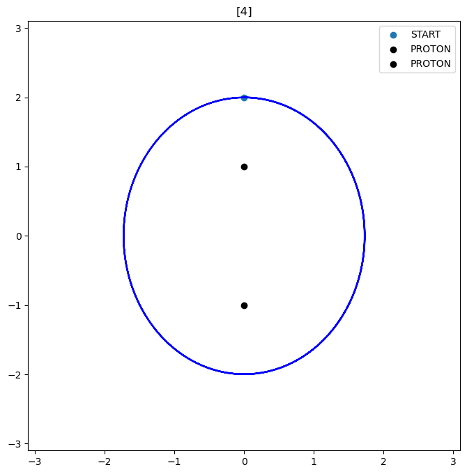

```python
v0 = 20.65
tol = 0.016
graph_num = 4

state0 = (0, 2, v0, 0)
sol1 = solve_ivp(diff_eqns, t_span, state0, rtol=1e-9, atol=1e-9, events = [cross, stability, distance_r, distance_l, distance_u, distance_b])

plot_func(sol1, graph_num, scale)
shape_checker(sol1, tol)
```

### Stable RaceTrack when tolerance = 0.512 (Low quality orbit)

```
'Stable Race Track'
```

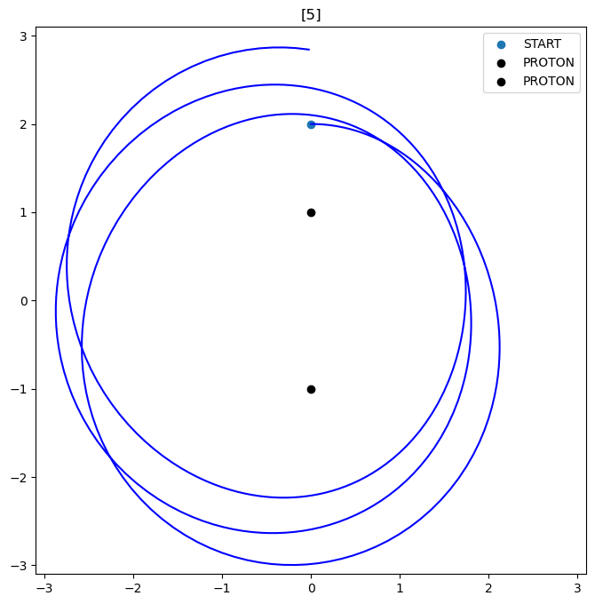

```python
v0 = 21.91
tol = 0.512
graph_num = 5

state0 = (0, 2, v0, 0)
sol1 = solve_ivp(diff_eqns, t_span, state0, rtol=1e-9, atol=1e-9, events = [cross, stability, distance_r, distance_l, distance_u, distance_b])

plot_func(sol1, graph_num, scale)
shape_checker(sol1, tol)
```

### Stable Orbit around 1 Proton when tolerance = 0.064 (Interesting orbit)

```
'Stable Orbit around one proton'
```

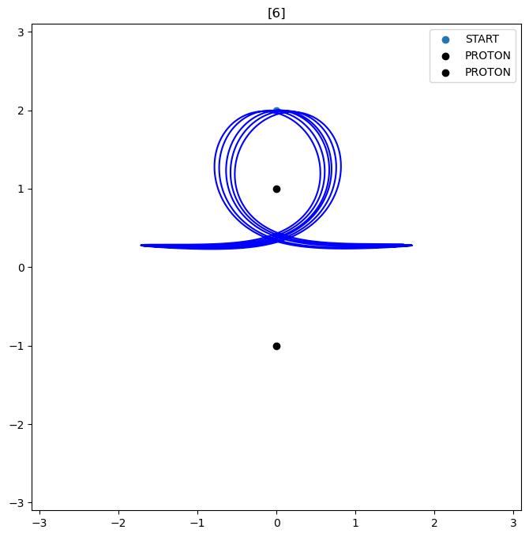

```python
v0 = 12.97
tol = 0.064
graph_num = 6

state0 = (0, 2, v0, 0)
sol1 = solve_ivp(diff_eqns, t_span, state0, rtol=1e-9, atol=1e-9, events = [cross, stability, distance_r, distance_l, distance_u, distance_b])

plot_func(sol1, graph_num, scale)
shape_checker(sol1, tol)
```

### Stable 'Figure 8' when tolerance = 0.016 (Interesting orbit)

```
'Stable Figure 8'
```

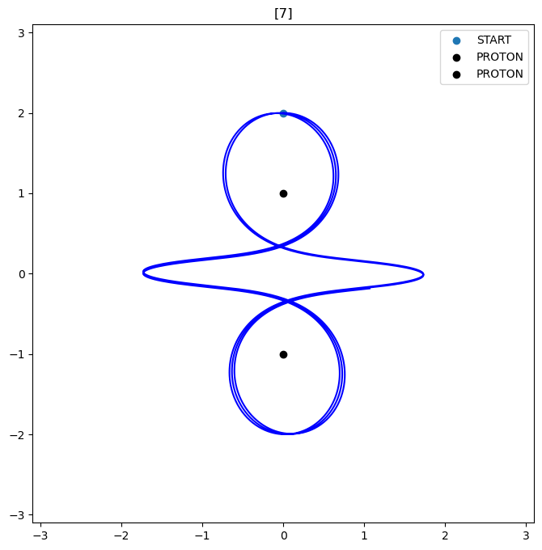

```python
v0 = 13.15
tol = 0.016
graph_num = 7

state0 = (0, 2, v0, 0)
sol1 = solve_ivp(diff_eqns, t_span, state0, rtol=1e-9, atol=1e-9, events = [cross, stability, distance_r, distance_l, distance_u, distance_b])

plot_func(sol1, graph_num, scale)
shape_checker(sol1, tol)
```

### Stable 'Figure 8' when tolerance = 0.0.16 (Interesting orbit)

```
'Stable Figure 8'
```

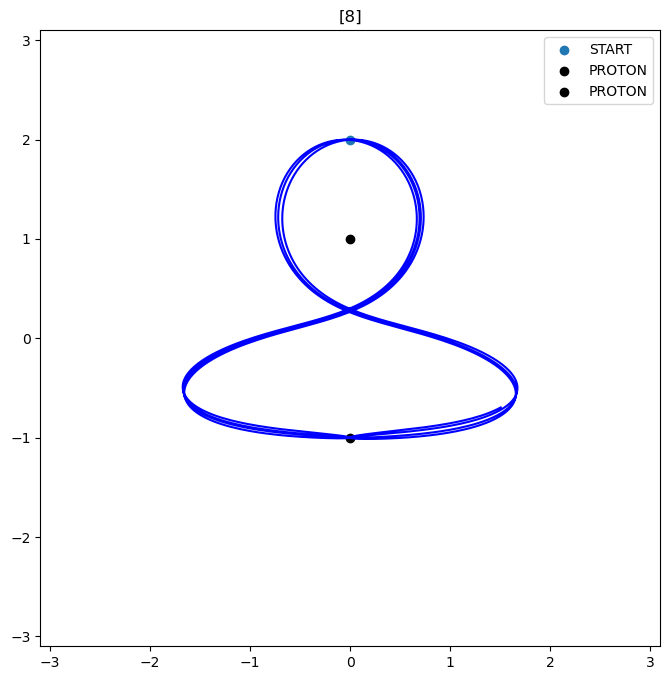

```python
v0 =  13.48
tol = 0.016
graph_num = 8


state0 = (0, 2, v0, 0)
sol1 = solve_ivp(diff_eqns, t_span, state0, rtol=1e-9, atol=1e-9, events = [cross, stability, distance_r, distance_l, distance_u, distance_b])

plot_func(sol1, graph_num, scale)
shape_checker(sol1, tol)
```

### Stable 'Figure 8' when tolerance = 0.0.16 (Interesting orbit)

```
'Stable Figure 8'
```

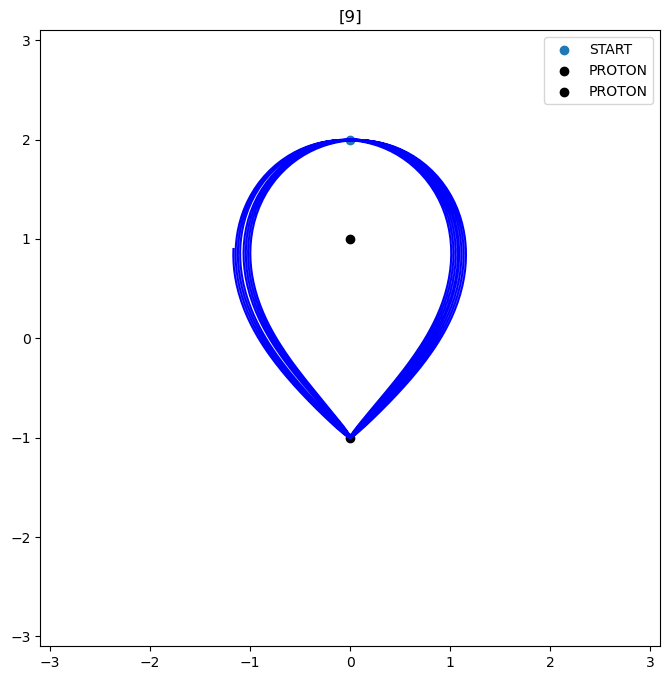

```python
v0 =  17.19
tol = 0.016
graph_num = 9
state0 = (0, 2, v0, 0)
t_span = (0, 3)
sol1 = solve_ivp(diff_eqns, t_span, state0, rtol=1e-9, atol=1e-9, events = [cross, stability, distance_r, distance_l, distance_u, distance_b])

plot_func(sol1, graph_num, scale)
shape_checker(sol1, tol)
```

### Testing window

```python
# This window was used to verify ...
# The now highlighted points were actually interesting. (the function 'interesting_values()' prints every point for each orbit num)
# used to verify functions were working in a separate code window
# code did not crash for various tests -
# if I understood how functions and scope actually worked


# all comments are comments to myself as i started making the code
v0 = 14.624            # velocity (shape)
v0 = 12.97
# v0 = 20.65
v0 = 13.48
v0 = 17.19
t_span = (0, 3)         # duration
scale = 1               # how zoomed in the graph is (used for testing for v)
tolerance = 0.064           #how strict 'stability' is

# CALCULATE
state0 = (0, 2, v0, 0)
sol1 = solve_ivp(diff_eqns, t_span, state0, rtol=1e-9, atol=1e-9, events = [cross, stability, distance_r, distance_l, distance_u, distance_b])


# WHICH RESULTS WE WANT TO SEE
# plot_func(sol1, scale)
# shape_checker(sol1, tolerance)
```

# Conclusion

Using all the graphs above we can get a better understanding of which tolerance makes the most sense.

Looking at the highest tolerance values in graph 1, we see that there are many more stable orbits. This is because as the tolerance increases, our definition of stable becomes less strict. Looking at graph 5 makes us realize this is not a good thing. This orbit is way to chaotic to be classified as stable and thus we can consider any high tolerance value (>=0.512) as too forgiving and unusable.

Looking at graph 6 we can see that although its much less chaotic than graph 5, it still deviates from a clean symmetrical orbit and over even more time would become chaotic. Using this last graph narrows our range of acceptable tolerances to 0.016 and 0.032. Mostly all orbits that are stable when our tolerance = 0.032 are considered as stable when our tolerance = 0.016. Picking the most strict tolerance value that still matches our graphical expectations leaves us with a tolerance of 0.016.

Thus our definition for stability is: A 'Stable' orbit refers to an orbit where an electron completes a full orbit such that when $x = x_{initial}$ our difference, $|y-y_{initial}|$ is less than 0.016[m]

One thing that we did not yet mention is the new shapes that appeared (graphs 6,7,8). Below will look into them more.

# Start of Code 2

The purpose of this section is to investigate the area around our new shapes.

### New calculations

```python
# ends the loop earlier to save time
def unstable(t, state):
    x, y, vx, vy = state
    xtol = 1e-3
    ytol = 0.016
    if y > 0 and x < xtol and x > 0:
        return (abs(y - 2) - ytol)
    return -1
unstable.terminal = True
unstable.direction = 1

# used to count duration of the orbit, one increment is not equal to one orbit.
def orbits(t, state):
    x, y, vx, vy = state
    return x
orbits.terminal = False
orbits.direction = 1





h_results_to_graph = [] # results/findings go in here
t_span = (0, 50)        # runs for much longer now - includes new break events
tol = 0.016             # tolerance value

#calculation loop
for vel in range(1200,2400):
    v0 = vel / 100      # finding each v0 per iteration


    # solve_IVP calculations
    state0 = (0, 2, v0, 0)
    sol1 = solve_ivp(diff_eqns, t_span, state0, rtol=1e-9, atol=1e-9, events = [cross, stability, unstable, orbits, distance_u, distance_b, distance_l, distance_r])


    # duration of orbit
    orbit = len(sol1.t_events[3])

    # saving each velocity and orbit duration for the heat map
    h_results_to_graph.append([v0, orbit])


    # To make sure its actually running and keep me sane
    #print(orbit)
    #print(f'Updater {vel}')
    if vel % 400 == 0: print('Still working')
```

```
Still working
Still working
Still working
```

### Saving data to a CSV

```python
data3 = {'Colors': v_values, 'Orbits': orbit_counts}
df3 = pd.DataFrame(data3)
df3.to_csv('HeatMap.csv', index = False)
```

### Getting data from CSV

```python
df3 = pd.read_csv('HeatMap.csv')
h_results_to_graph = df3.iloc[:, :2].to_numpy()
```

### Graphing

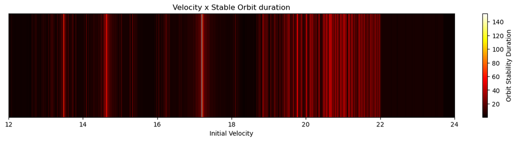

```python
data = np.array(h_results_to_graph)
v_values = data[:, 0]
orbit_counts = data[:, 1]
# This has to be done as all the none racetrack shapes (v<19) cross twice as much
orbit_counts[v_values > 19] /= 2

plt.figure(figsize=(16, 3))
plt.imshow(orbit_counts[np.newaxis, :], cmap='hot', aspect='auto', extent=[12, 24, 0, 1])
plt.colorbar(label='Orbit Stability Duration')
plt.xlabel('Initial Velocity')
plt.yticks([])
plt.title('Velocity x Stable Orbit duration')
plt.show()
```

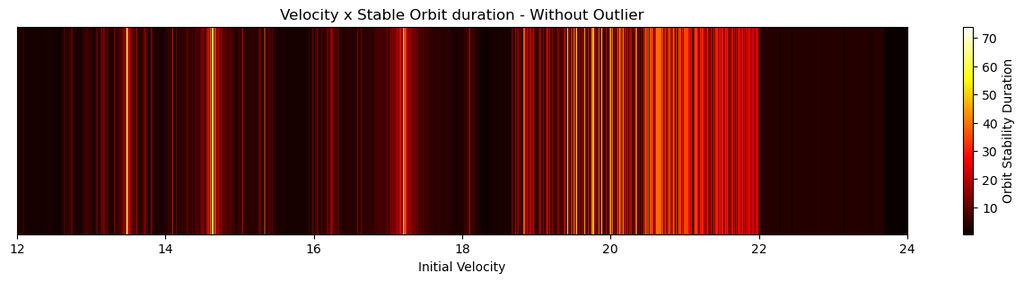

```python
plt.figure(figsize=(16, 3))
orbit_counts = data[data[:, 1] < 100, 1]
plt.imshow(orbit_counts[np.newaxis, :], cmap='hot', aspect='auto', extent=[12, 24, 0, 1])
plt.colorbar(label='Orbit Stability Duration')
plt.xlabel('Initial Velocity')
plt.yticks([])
plt.title('Velocity x Stable Orbit duration - Without Outlier')
plt.show()
```

# Conclusion 2

From both heat maps above, the whiter the line, the longer the orbit will be stable for. We see a pattern of the whitest lines around the v0 values that were stable in graph 2. We can see that to the right and left of each of these lines are slightly darker lines that indicate that the orbit was stable for slightly less orbits. We can also assume that any white line would will run indefinitely.

This second graph does a better job of represeting the data set by telling us that there are more v0 values that create semi-stable orbits (temporarly stable) and intersting shapes than originally thought, which is to be after the first conclusion/set of graphs.

The heatmap also shows us regions where we are more likely to find a stable orbit (right side) as compared to regions were there are very few stable orbits (left and middle).

One thing to look further into would be why there is such an outlier for the point at v0 = 17.19 when graphs 3 and 4 look so much 'more stable/perfect'.